```python
%matplotlib inline
```

# Statistical model to extrapolate Covid-19 actives cases

Here we build the statistical model behind https://covid19-dash.github.io/

The model is made by fitting a weighted least square on the log of the number of cases over a window of the few last days.

This is a computational notebook: it is the actual code that is run to build the model.

Use joblib, to speed up interactions

```python
from joblib import Memory
mem = Memory(location='.')
```

## Load and plot the data

Download the data

```python
import data_input
data = mem.cache(data_input.get_data)()


# We model only the confirmed cases
confirmed = data['confirmed']
```

First plot the time course of the most affected countries

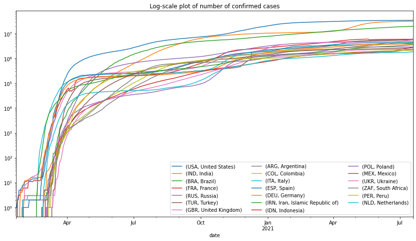

```python
last_day = confirmed.iloc[-1]
most_affected_countries = confirmed.columns[last_day.argsort()][::-1]

import matplotlib.pyplot as plt
ax = confirmed[most_affected_countries[:20]].plot(figsize=(12, 7))
ax.set_yscale('log')
ax.set_title("Log-scale plot of number of confirmed cases")
plt.legend(loc='best', ncol=3)
plt.tight_layout()
```

## Define our weighted window

The windows that we use are weighted: we give more weight to the last day, and less to the days further away in time.

Some functions to build normalized weighted windows

```python
import numpy as np

def ramp_window(start=14, middle=7):
    window = np.ones(start)
    window[:middle] = np.arange(middle) / float(middle)
    window /= window.sum()
    return window


def exp_window(start=14, growth=1.1):
    window = growth ** np.arange(start)
    window /= window.sum()
    return window
```

To define the optimal window, specified below, we used a historical replay: we chose the window and the set of weights that predict been observations already seen from their past

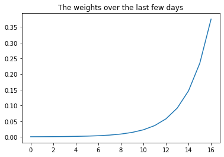

```python
window_size = 17
weighted_window = exp_window(start=window_size, growth=1.6)

plt.figure()
plt.plot(weighted_window)
plt.title('The weights over the last few days')
```

# A simple model: fit the last few points

the log of the confirmed counts in the last fortnight

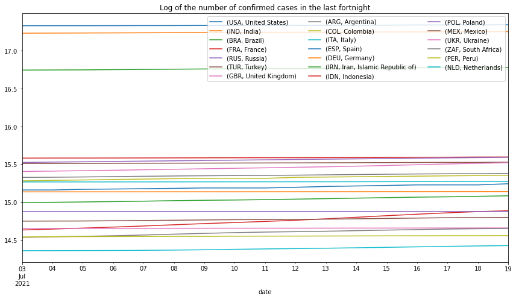

```python
last_fortnight = confirmed.iloc[-window_size:]
np.seterr(divide='ignore')
log_last_fortnight = np.log(last_fortnight)
log_last_fortnight[log_last_fortnight == -np.inf] = 0

ax = log_last_fortnight[most_affected_countries[:20]].plot(figsize=(12, 7))
ax.set_title('Log of the number of confirmed cases in the last fortnight')
plt.legend(loc='best', ncol=3)
plt.tight_layout()
```

Our model-fitting routine: a weighted least square on the log of the confirmed counts

The errors in the data are expected to be proportional to the value of the data: the more cases are present, the more tests are realized, and the more errors as well as the more cases are missed. This noise becomes additive after taking the log, and can then reasonnably be assumed Gaussian, which justifies the use of a squared loss.

```python
import pandas as pd
import statsmodels.api as sm

def fit_on_window(data, window):
    """ Fit the last window of the data
    """
    window_size = len(window)
    last_fortnight = data.iloc[-window_size:]
    log_last_fortnight = np.log(last_fortnight)
    log_last_fortnight[log_last_fortnight == -np.inf] = 0

    design = pd.DataFrame({'linear': np.arange(window_size),
                           'const': np.ones(window_size)})

    growth_rate = pd.DataFrame(data=np.zeros((1, len(data.columns))),
                               columns=data.columns)

    predicted_cases = pd.DataFrame()
    predicted_cases_lower = pd.DataFrame()
    predicted_cases_upper = pd.DataFrame()
    prediction_dates = pd.date_range(data.index[-window_size],
                                    periods=window_size + 7)

    for country in data.columns:
        mod_wls = sm.WLS(log_last_fortnight[country].values, design,
                         weights=window, hasconst=True)
        res_wls = mod_wls.fit()
        growth_rate[country] = np.exp(res_wls.params.linear)
        predicted_cases[country] = np.exp(res_wls.params.const +
                res_wls.params.linear * np.arange(len(prediction_dates))
            )
        # 1st and 3rd quartiles in the confidence intervals
        conf_int = res_wls.conf_int(alpha=.25)
        # We chose to account only for error in growth rate, and not in
        # baseline number of cases
        predicted_cases_lower[country] = np.exp(res_wls.params.const +
                conf_int[0].linear * np.arange(len(prediction_dates))
            )
        predicted_cases_upper[country] = np.exp(res_wls.params.const +
                conf_int[1].linear * np.arange(len(prediction_dates))
            )

    predicted_cases = pd.concat(dict(prediction=predicted_cases,
                                     lower_bound=predicted_cases_lower,
                                     upper_bound=predicted_cases_upper),
                                axis=1)
    predicted_cases['date'] = prediction_dates
    predicted_cases = predicted_cases.set_index('date')
    if window_size > 10:
        # Don't show predictions more than 10 days ago
        predicted_cases  = predicted_cases.iloc[window_size - 10:]

    return growth_rate, predicted_cases
```

Fit it on the data

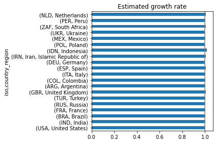

```python
growth_rate, predicted_cases = fit_on_window(confirmed, weighted_window)

ax = growth_rate[most_affected_countries[:20]].T.plot(kind='barh',
    legend=False)
ax.set_title('Estimated growth rate')
ax.axvline(1, color='.5')
plt.tight_layout()
```

Display the estimated growth rates

```python
pd.set_option('display.max_rows', 60)
growth_rate[most_affected_countries[:60]].T
```

| iso | country_region | 0 |
| --- | --- | --- |
| USA | United States | 1.000967 |
| IND | India | 1.001222 |
| BRA | Brazil | 1.001949 |
| FRA | France | 1.001413 |
| RUS | Russia | 1.004216 |
| TUR | Turkey | 1.001240 |
| GBR | United Kingdom | 1.008583 |
| ARG | Argentina | 1.002940 |
| COL | Colombia | 1.004164 |
| ITA | Italy | 1.000574 |
| ESP | Spain | 1.005650 |
| DEU | Germany | 1.000316 |
| IRN | Iran, Islamic Republic of | 1.006128 |
| IDN | Indonesia | 1.017368 |
| POL | Poland | 1.000030 |
| MEX | Mexico | 1.003477 |
| UKR | Ukraine | 1.000424 |
| ZAF | South Africa | 1.006116 |
| PER | Peru | 1.000826 |
| NLD | Netherlands | 1.005609 |
| CZE | Czech Republic | 1.000133 |
| CHL | Chile | 1.001088 |
| PHL | Philippines | 1.003568 |
| IRQ | Iraq | 1.006040 |
| CAN | Canada | 1.000275 |
| BGD | Bangladesh | 1.010868 |
| BEL | Belgium | 1.001210 |
| SWE | Sweden | 1.000153 |
| ROU | Romania | 1.000049 |
| PAK | Pakistan | 1.002428 |
| PRT | Portugal | 1.003423 |
| MYS | Malaysia | 1.012997 |
| ISR | Israel | 1.000998 |
| JPN | Japan | 1.003641 |
| HUN | Hungary | 1.000056 |
| JOR | Jordan | 1.000648 |
| SRB | Serbia | 1.000221 |
| CHE | Switzerland | 1.000715 |
| NPL | Nepal | 1.002399 |
| ARE | United Arab Emirates | 1.002337 |
| AUT | Austria | 1.000467 |
| MAR | Morocco | 1.003846 |
| LBN | Lebanon | 1.000778 |
| TUN | Tunisia | 1.012261 |
| KAZ | Kazakhstan | 1.007004 |
| SAU | Saudi Arabia | 1.001503 |
| ECU | Ecuador | 1.002042 |
| BOL | Bolivia | 1.002402 |
| GRC | Greece | 1.005236 |
| PRY | Paraguay | 1.002149 |
| BLR | Belarus | 1.002192 |
| PAN | Panama | 1.002321 |
| BGR | Bulgaria | 1.000167 |
| THA | Thailand | 1.027110 |
| CRI | Costa Rica | 1.003267 |
| SVK | Slovakia | 1.000067 |
| GEO | Georgia | 1.003657 |
| KWT | Kuwait | 1.003511 |
| URY | Uruguay | 1.000795 |
| HRV | Croatia | 1.000285 |

Plot our prediction

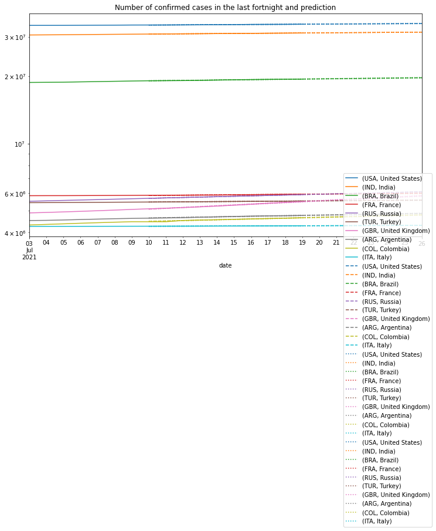

```python
ax = last_fortnight[most_affected_countries[:10]].plot(figsize=(12, 7))
predicted_cases['prediction'][most_affected_countries[:10]].plot(
        ax=ax, style='--')
predicted_cases['lower_bound'][most_affected_countries[:10]].plot(
        ax=ax, style=':')
predicted_cases['upper_bound'][most_affected_countries[:10]].plot(
        ax=ax, style=':')

plt.legend(loc=(.8, -1.3))
ax.set_yscale('log')
ax.set_title('Number of confirmed cases in the last fortnight and prediction')
```

Save our results for the dashboard. We pickle a dict, because hierachical columns do not pickle right

```python
import pickle
with open('predictions.pkl', 'wb') as out_file:
    pickle.dump(dict(prediction=predicted_cases['prediction'],
                     lower_bound=predicted_cases['lower_bound'],
                     upper_bound=predicted_cases['upper_bound'],
                    ),
                out_file)
```